# **Dinoaurios**

Los dinosaurios son un grupo diverso de reptiles que dominaron la Tierra durante más de 160 millones de años, desde el período Triásico, hace unos 231 millones de años, hasta su extinción en el Cretácico, hace unos 66 millones de años. Durante su tiempo en la Tierra, los dinosaurios evolucionaron en una variedad de tamaños, formas y hábitos, desde pequeños herbívoros que se alimentaban de plantas hasta enormes carnívoros depredadores.

La palabra “dinosaurio” proviene del griego “deinos” que significa “terrible” o “temible”, y “sauros” que significa “lagarto”. Esta palabra fue acuñada por el paleontólogo británico Richard Owen en 1842, cuando describió por primera vez los fósiles de un grupo de reptiles prehistóricos que ahora se conocen como dinosaurios.

Los dinosaurios se clasifican en dos grandes grupos: los saurisquios y los ornitisquios. Los saurisquios son dinosaurios con cadera de reptil, mientras que los ornitisquios tienen una cadera más parecida a la de las aves. Los saurisquios se dividen en dos subgrupos: terópodos, que son principalmente carnívoros, y saurópodos, que son herbívoros de gran tamaño. Los ornitisquios se dividen en varios subgrupos, incluyendo ceratópsidos, estegosáuridos y hadrosáuridos.

Entre los dinosaurios más conocidos se encuentran el Tiranosaurio Rex, el Triceratops, el Estegosaurio y el Velociraptor. El Tiranosaurio Rex, también conocido como T-Rex, es uno de los mayores depredadores terrestres conocidos, con una longitud de hasta 12 metros y un peso de hasta 8 toneladas. El Triceratops era un herbívoro con tres cuernos distintivos en su cabeza, mientras que el Estegosaurio tenía placas óseas en su espalda y una cola con púas. El Velociraptor, a pesar de su nombre, no era tan grande como se pensaba originalmente y era un depredador bípedo con garras afiladas en sus extremidades.

Los dinosaurios eran animales fascinantes y aún hay mucho que aprender sobre ellos. Los paleontólogos han descubierto muchos fósiles de dinosaurios, lo que nos ha permitido reconstruir sus esqueletos y tener una idea de cómo se veían y se movían. También se han hecho descubrimientos importantes sobre su comportamiento, como la creencia de que algunos dinosaurios eran animales sociales que vivían en manadas, mientras que otros eran solitarios.

La extinción de los dinosaurios es uno de los eventos más intrigantes de la historia de la Tierra. Se cree que un asteroide impactó la Tierra hace unos 66 millones de años, lo que desencadenó una serie de eventos que condujeron a su extinción. Sin embargo, algunos lograron sobrevivir y evolucionaron en aves modernas que aún viven en la actualidad.

En la cultura popular, los dinosaurios han sido representados de muchas maneras, desde feroces depredadores hasta criaturas amigables y divertidas.

[figure not shown]

> *Aguilar, F. G. (2020, 24 julio). Dinosaurios: las pruebas de su vida en la Tierra. Gaceta UNAM*.  
> [Gaceta UNAM](https://www.gaceta.unam.mx/dinosaurios-las-pruebas-de-su-vida-en-la-tierra)

## **Tipos de Dinosurios**

Los dinosuarios se clasifican de acuerdo a la estructura de la cadera: Cadera de lagarto y Cadera de Ave.  
Algunos especímenes:

### Saurisquios

1. **Arqueopterix**
2. **Alosaurio**
3. **Diplodocus**
4. **Tiranosaurio**
5. **Espinosaurio**

### Ornitrisquios

1. **Triceratops**
2. **Estegosaurio**
3. **Parasaurolofus**
4. **Anquilosaurio**
5. **Apatosaurio**

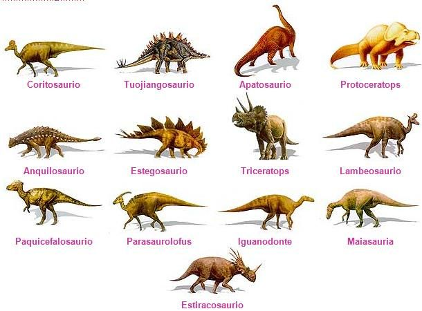

*La informacion de este articulo fue tomada mayormente de la pagina:* [Dinosaurios](https://www.revista.unam.mx/vol.2/num4/sabias1/tipos.html)